# Auswertung TC Daten

David Lilek

12 Juli 2023, 10:09:22

# 1 Load Libraries & Plot function

```r
library(ggplot2)
library(tidyverse)
library(dplyr)
library(UpSetR)
library(pheatmap)
library(ggvenn)
library(knitr)
library(reshape2)
library(eulerr)
#library(venneuler)
#library(VennDiagram)
```

```r
euler_venn_2comp <- function(lst, label_venn, color_venn, cex_venn, grid, gList, h_just, v_just) {
  ######################################
  #################plot 2 venn diagrams
  ######################################
  p<-plot(euler(lst),
          input="union",
          shape="ellipse",
          quantities=list(type = c("percent", 'counts'),
                          cex = cex_venn), #schriftgröße für A, B bzw intersection
          key=TRUE,
          labels=FALSE,
          lty = c(1,1),
          legend = list(labels = label_venn,
                        side = "bottom",
                        nrow = 1, ncol = 3),
          edges=TRUE,
          fills = color_venn, #color für A,B bzw intersection
          alpha=0.8)
  # https://stackoverflow.com/questions/75177293/how-to-change-the-label-position-when-plotting-venn-diagram-from-eulerr-package
  tags <- p$children[[2]]$children[[1]]$children$tags$children
  tags <- do.call(grid::gList, lapply(tags, function(x) {
    x$children[[2]]$label <- sub(" \\(", "\n(", x$children[[2]]$label)
    x$children[[2]]$just <- NULL
    x$children[[2]]$hjust <- h_just
    x$children[[2]]$vjust <- v_just
    x}))

  p$children[[2]]$children[[1]]$children$tags$children <- tags
  print(p)
}


euler_venn_3comp <- function(lst, cex_venn, label_venn, color_venn, grid, gList, h_just, v_just) {
  ##################################
  ###### venn diagram 3 comparisons
  ##################################
  p<-plot(euler(lst),
          input="union",
          shape="ellipse",
          quantities=list(type = c("percent", 'counts'),
                          cex = cex_venn), #schriftgröße für A, B, C bzw intersection
          key=TRUE,
          labels=FALSE,
          lty = c(1,1,1),
          legend = list(labels = label_venn,
                        side = "bottom",
                        nrow = 1, ncol = 3),
          edges=TRUE,
          fills = color_venn, #color für A,B bzw intersection fills = grey[c(10,18,25)]
          alpha=0.8)
  # https://stackoverflow.com/questions/75177293/how-to-change-the-label-position-when-plotting-venn-diagram-from-eulerr-packages
  tags <- p$children[[2]]$children[[1]]$children$tags$children
  tags <- do.call(grid::gList, lapply(tags, function(x) {
    x$children[[2]]$label <- sub(" \\(", "\n(", x$children[[2]]$label)
    x$children[[2]]$just <- NULL
    x$children[[2]]$hjust <- h_just
    x$children[[2]]$vjust <- v_just
    x}))

  p$children[[2]]$children[[1]]$children$tags$children <- tags
  print(p)
}
```

# 2 Vergleich Messreplikate Standardabweichung

- Taking a closer look the standard deviation of measurement replicates it is obvious that the standard deviation depends stronly on the number of identified proteins. Below 200 proteins a rsd of 5.24% was calculated. Above 200 proteins a significantly lower rsd of 1.57% was observed (p-value = 0.001608).
- die Messungen wurden in Triplikaten und Duplikaten durchgeführt
- für jedes Triplikat/Duplikat wurde sd und mean berechnet und geplottet
- es zeigt sich, dass die Messreproduzierbarkeit von der Anzahl der Proteine abhängt
- <200 Proteine: median relative sd = 5.235318
- >200 proteine: median realtive sd = 1.568858

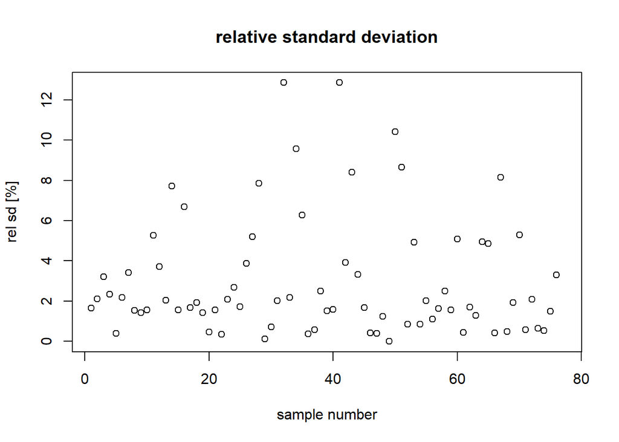

```r
data <- read.csv("Extraktionen_gesamt_V2_DL.csv", sep=";")
sample_group <- c(seq(1,18,by=3),seq(19,162,by=2))
sd_samples <- c()
mean_samples <- c()
for (i in 1:length(sample_group)){
  if (i<78){
  tmp <- sd(data$Unique.no.MBR.2.peptides[sample_group[i]:(sample_group[i+1]-1)])
  sd_samples <- c(sd_samples, tmp)
  tmp <- mean(data$Unique.no.MBR.2.peptides[sample_group[i]:(sample_group[i+1]-1)])
  mean_samples <- c(mean_samples,tmp)
  } else {
    tmp <- sd(data$Unique.no.MBR.2.peptides[sample_group[i]:length(data$Unique.no.MBR.2.peptides)])
    sd_samples <- c(sd_samples, tmp)
    tmp <- mean(data$Unique.no.MBR.2.peptides[sample_group[i]:length(data$Unique.no.MBR.2.peptides)])
    mean_samples <- c(mean_samples,tmp)
  }
}

plot(sd_samples[-31]/mean_samples[-31]*100,main="relative standard deviation",ylab="rel sd [%]",xlab="sample number")
```

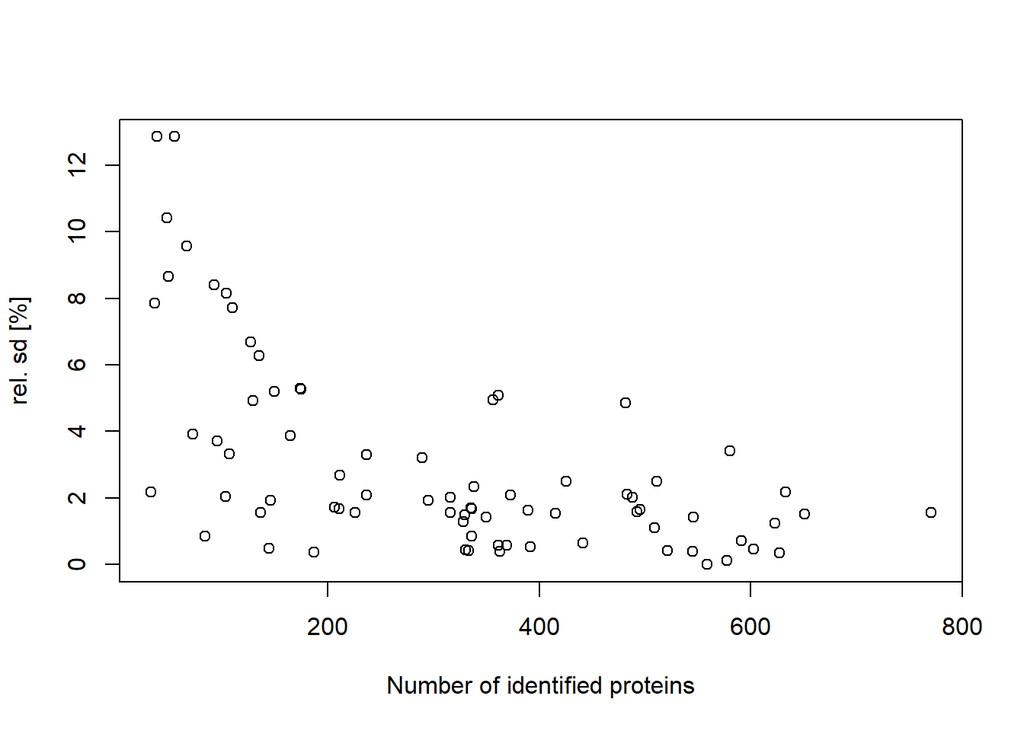

```r
plot(mean_samples[-31],sd_samples[-31]/mean_samples[-31]*100,ylab="rel. sd [%]",xlab="Number of identified proteins")
```

```r
rel_sd <- sd_samples/mean_samples*100
median(rel_sd[which(mean_samples<200)])
```

```
## [1] 5.235318
```

```r
median(rel_sd[which(mean_samples>200)])
```

```
## [1] 1.568858
```

```r
#t test rel sd <200 with rel sd >200
t.test(rel_sd[which(mean_samples<200)],rel_sd[which(mean_samples>200)])
```

```
##
##  Welch Two Sample t-test
##
## data:  rel_sd[which(mean_samples < 200)] and rel_sd[which(mean_samples > 200)]
## t = 3.293, df = 64.766, p-value = 0.001608
## alternative hypothesis: true difference in means is not equal to 0
## 95 percent confidence interval:
##  1.269247 5.182050
## sample estimates:
## mean of x mean of y
##  5.553882  2.328234
```

# 3 Comparison E3_D1 - noTreatment, Heatshock, ProteaseInhibitor

ACHTUNG: Die Anzahl der oben genannten Proteine beziehen sich auf die Bildung des einfachen Mittelwertes. Hier wenn man merged und die “wirkliche” Anzahl an Proteinen gibt.

```r
#E3_D1
D1_raw <- readRDS(file = "results_v002/results_run1_mqpar_extracts_2gether_E3_D1_LFQ_combined_txt_proteinGroups.txt_Unique.RDS")
D1_raw <- D1_raw[[1]]

D1 <- D1_raw[,-ncol(D1_raw)]
D1 <- D1*1

noT <- apply(D1[,c(1:6)], 1, any)
HS <- apply(D1[,c(7:12)],1,any)
PI <- apply(D1[,c(13:18)],1,any)
print("no Treatment")
```

```
## [1] "no Treatment"
```

```r
sum(noT*1)
```

```
## [1] 643
```

```r
print("Heatshock")
```

```
## [1] "Heatshock"
```

```r
sum(HS*1)
```

```
## [1] 419
```

```r
print("Protease Inhibitor")
```

```
## [1] "Protease Inhibitor"
```

```r
sum(PI*1)
```

```
## [1] 774
```

```r
data <- read.csv("Extraktionen_gesamt_V2_DL.csv", sep=";")
data_sub <- as.data.frame(data$Unique.no.MBR.2.peptides)
data_sub <- as.data.frame(data_sub[c(1:18),])
data_sub$group <- c(rep("noTreatment",6),
                   rep("Heatshock",6),
                   rep("ProteaseInhibitor",6))
colnames(data_sub) <- c("number","group")
print("Median no Treatment")
```

```
## [1] "Median no Treatment"
```

```r
median(subset(data_sub,group=="noTreatment")[,1])
```

```
## [1] 490.5
```

```r
print("Median Heatshock")
```

```
## [1] "Median Heatshock"
```

```r
median(subset(data_sub,group=="Heatshock")[,1])
```

```
## [1] 314.5
```

```r
print("Median ProteaseInhibitor")
```

```
## [1] "Median ProteaseInhibitor"
```

```r
median(subset(data_sub,group=="ProteaseInhibitor")[,1])
```

```
## [1] 586
```

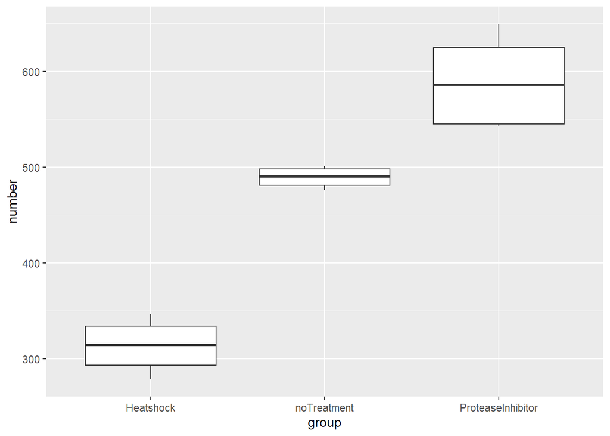

```r
ggplot(data_sub, aes(x=group, y=number)) +
  geom_boxplot()
```

```r
anova <- aov(number ~ group, data=data_sub)
summary(anova)
```

```
##             Df Sum Sq Mean Sq F value   Pr(>F)
## group        2 232951  116476   105.9 1.43e-09 ***
## Residuals   15  16506    1100
## ---
## Signif. codes:  0 '***' 0.001 '**' 0.01 '*' 0.05 '.' 0.1 ' ' 1
```

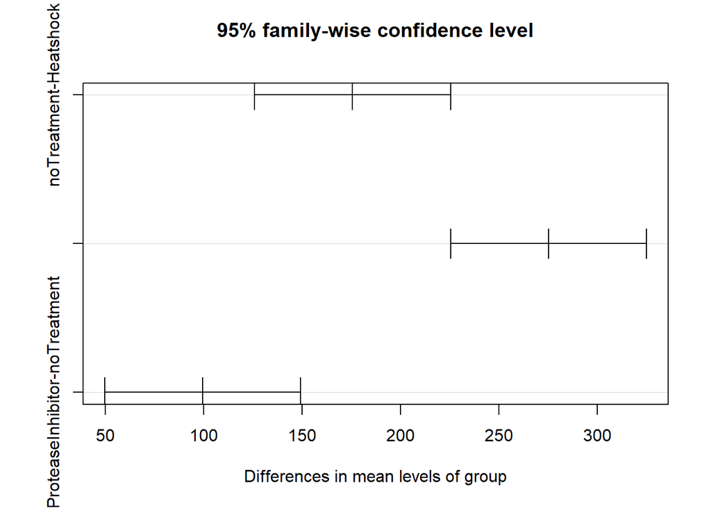

```r
Tukey <- TukeyHSD(anova)
plot(Tukey)
```

```r
Tukey
```

```
##   Tukey multiple comparisons of means
##     95% family-wise confidence level
##
## Fit: aov(formula = number ~ group, data = data_sub)
##
## $group
##                                   diff       lwr      upr     p adj
## noTreatment-Heatshock         175.6667 125.92061 225.4127 0.0000004
## ProteaseInhibitor-Heatshock   275.1667 225.42061 324.9127 0.0000000
## ProteaseInhibitor-noTreatment  99.5000  49.75394 149.2461 0.0003018
```

# 4 E4 - D1 - B - AF - TF

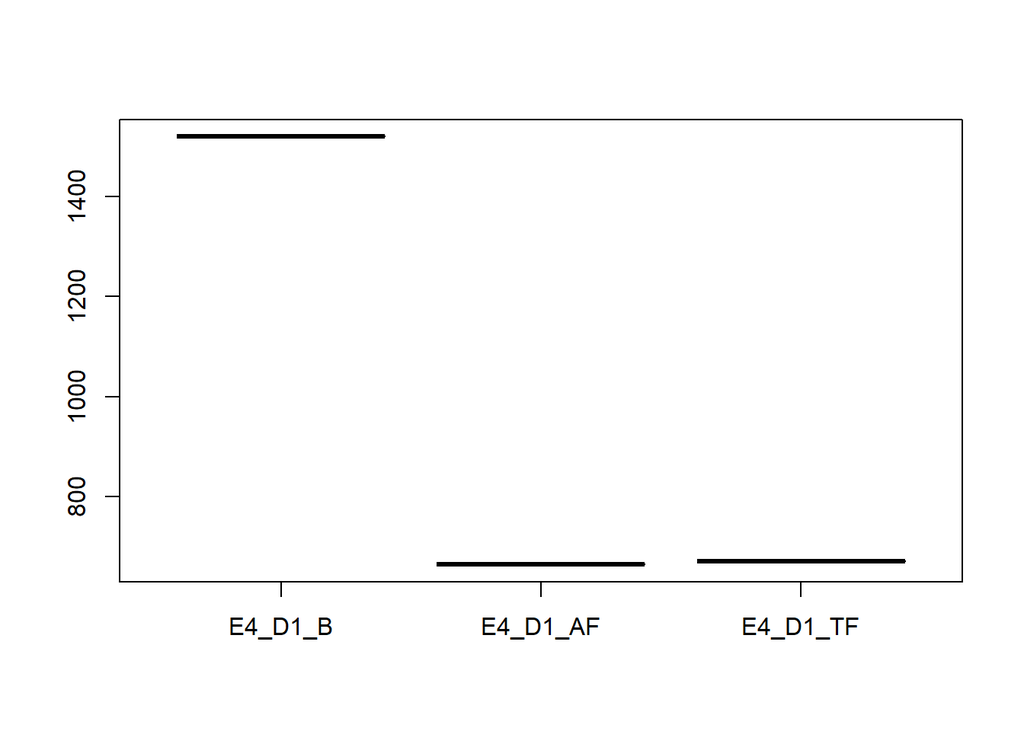

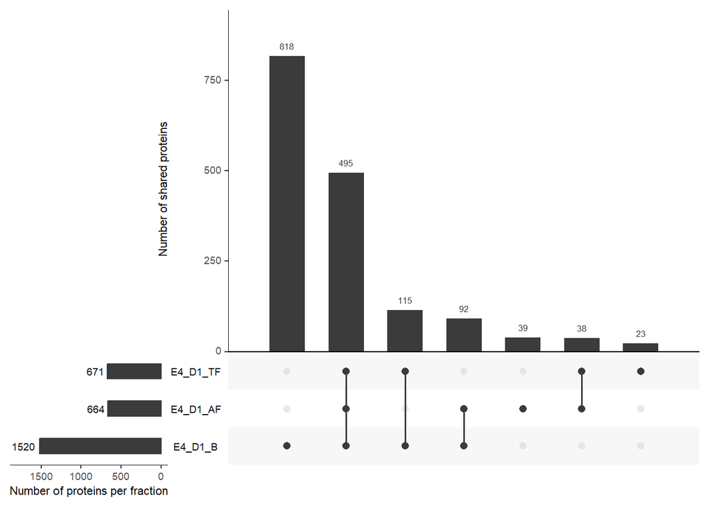

```r
############## B
data <- readRDS(file = "results_v002/results_run1_mqpar_extracts_2gether_E4_D1_B_LFQ_combined_txt_proteinGroups.txt_Unique.RDS")
data <- data[[1]]
data_sub <- dplyr::select(data, contains("Pool_G"))
#get rid of FALSE values
B <- data_sub*1
B[B==0] <- NA
ind <- apply(B, 1, function(x) all(is.na(x)))


############AF
data <- readRDS(file = "results_v002/results_run1_mqpar_extracts_2gether_E4_D1_AF_TF_LFQ_combined_txt_proteinGroups.txt_Unique.RDS")
data <- data[[1]]
data_sub <- dplyr::select(data, contains("Pool_AF"))
#get rid of FALSE values
AF <- data_sub*1
AF[AF==0] <- NA
ind <- apply(AF, 1, function(x) all(is.na(x)))

############TF
data <- readRDS(file = "results_v002/results_run1_mqpar_extracts_2gether_E4_D1_AF_TF_LFQ_combined_txt_proteinGroups.txt_Unique.RDS")
data <- data[[1]]
data_sub <- dplyr::select(data, contains("Pool_TF"))
#get rid of FALSE values
TF <- data_sub*1
TF[TF==0] <- NA
ind <- apply(TF, 1, function(x) all(is.na(x)))


## compare AF TF B poster
AF_TF_raw <- readRDS(file = "results_v002/results_run1_mqpar_extracts_2gether_E4_D1_AF_TF_LFQ_combined_txt_proteinGroups.txt_Unique.RDS")
AF_TF_raw <- AF_TF_raw[[1]]
AF <- dplyr::select(AF_TF_raw, contains("AF"))
AF <- apply(AF, 1, any)
fasta <- c()
for (i in 1:length(AF_TF_raw$FASTA)){
  tmp <- strsplit(AF_TF_raw$FASTA[i],split='\\|')[[1]][2]
  fasta <- c(fasta,tmp)
}
AF <- as.data.frame(cbind(AF, fasta))
TF <- dplyr::select(AF_TF_raw, contains("TF"))
TF <- apply(TF, 1, any)
TF <- as.data.frame(cbind(TF, fasta))
B_raw <- readRDS(file = "results_v002/results_run1_mqpar_extracts_2gether_E4_D1_B_LFQ_combined_txt_proteinGroups.txt_Unique.RDS")
B_raw <- B_raw[[1]]
B <- dplyr::select(B_raw, contains("Pool_G"))
B <- apply(B, 1, any)
fasta <- c()
for (i in 1:length(B_raw$FASTA)){
  tmp <- strsplit(B_raw$FASTA[i],split='\\|')[[1]][2]
  fasta <- c(fasta,tmp)
}
B <- as.data.frame(cbind(B, fasta))

AF_TF_B_comparison  <- merge(B, AF,
                           all = TRUE,
                           by = "fasta")
AF_TF_B_comparison <- merge(AF_TF_B_comparison, TF,
                            all = TRUE,
                            by = "fasta")

AF_TF_B_comparison$B <- as.logical(AF_TF_B_comparison$B)
AF_TF_B_comparison$AF <- as.logical(AF_TF_B_comparison$AF)
AF_TF_B_comparison$TF <- as.logical(AF_TF_B_comparison$TF)
AF_TF_B_comparison <- AF_TF_B_comparison[,-1]*1
AF_TF_B_comparison[AF_TF_B_comparison==0] <- NA


# boxplot
boxplot(sum(AF_TF_B_comparison$B,na.rm = TRUE),
        sum(AF_TF_B_comparison$AF,na.rm = TRUE),
        sum(AF_TF_B_comparison$TF,na.rm = TRUE),
        names = c("E4_D1_B","E4_D1_AF","E4_D1_TF"))

proteins <- as.data.frame(which(!is.na(AF_TF_B_comparison), arr.ind=TRUE))

B <- proteins %>% dplyr::filter(col == 1)
AF <- proteins %>% dplyr::filter(col == 2)
TF <- proteins %>% dplyr::filter(col == 3)


# combine to list
lst <- list("E4_D1_B"=as.double(B[,1]),
            "E4_D1_AF"=as.double(AF[,1]),
            "E4_D1_TF"=as.double(TF[,1]))

upset(fromList(lst),
      order.by = "freq",
      nsets = 10,
      nintersects = 15,
      keep.order = TRUE,
      sets=c("E4_D1_B", "E4_D1_AF", "E4_D1_TF"),
      mainbar.y.label = "Number of shared proteins",
      sets.x.label = "Number of proteins per fraction",
      set_size.show = TRUE,
      set_size.angles = 0,
      set_size.scale_max = 1800
)
```

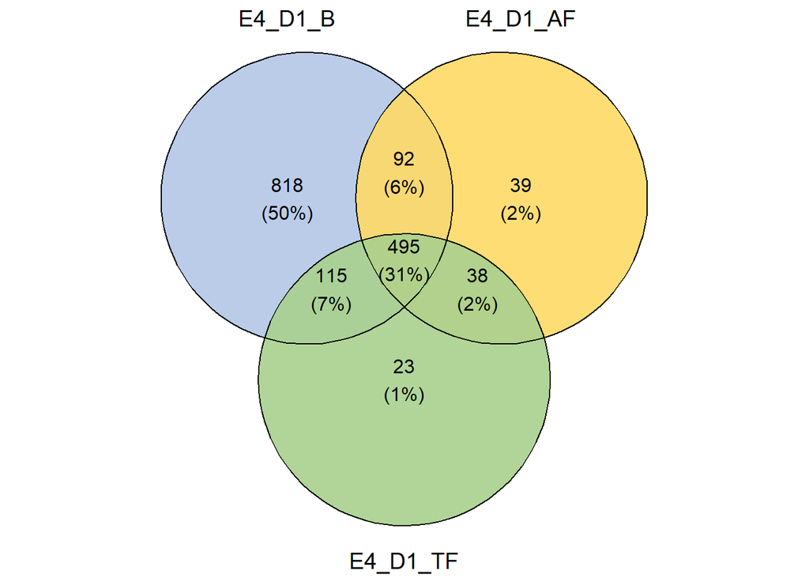

```r
#get colors
#total protein extract
total <- rgb(255,93,93, maxColorValue = 255)
#fractions high MW SEC
highMW <- rgb(169,208,142,maxColorValue = 255)
#fractions low MW SEC
lowMW <- rgb(255,217,102, maxColorValue = 255)
#in-gel digest
IG <- rgb(180,198,231,maxColorValue = 255)

ggvenn(lst,
       fill_color = c(IG,lowMW,highMW),
       stroke_size = 0.5, set_name_size = 5, text_size = 4.25, digits = 0, fill_alpha = 0.9, label_sep = )
```

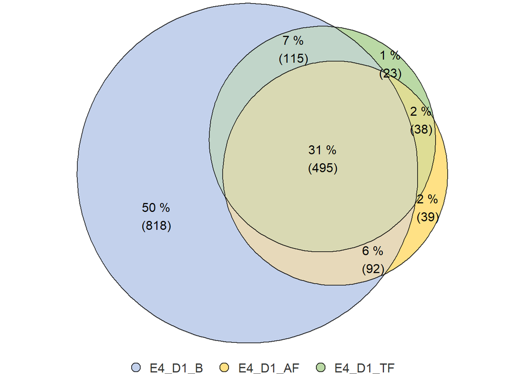

```r
#ggsave("./pics/unique_AF_TF_B.png")
euler_venn_3comp(lst, label_venn = c("E4_D1_B","E4_D1_AF","E4_D1_TF"), color_venn = c(IG,lowMW,highMW), cex_venn = c(1,1,1), h_just = 0.5, v_just = 0.5)
```

```r
print(c("E4_D1_B","E4_D1_AF","E4_D1_TF"))
```

```
## [1] "E4_D1_B"  "E4_D1_AF" "E4_D1_TF"
```

```r
sum(AF_TF_B_comparison$B,na.rm = TRUE)
```

```
## [1] 1520
```

```r
sum(AF_TF_B_comparison$AF,na.rm = TRUE)
```

```
## [1] 664
```

```r
sum(AF_TF_B_comparison$TF,na.rm = TRUE)
```

```
## [1] 671
```

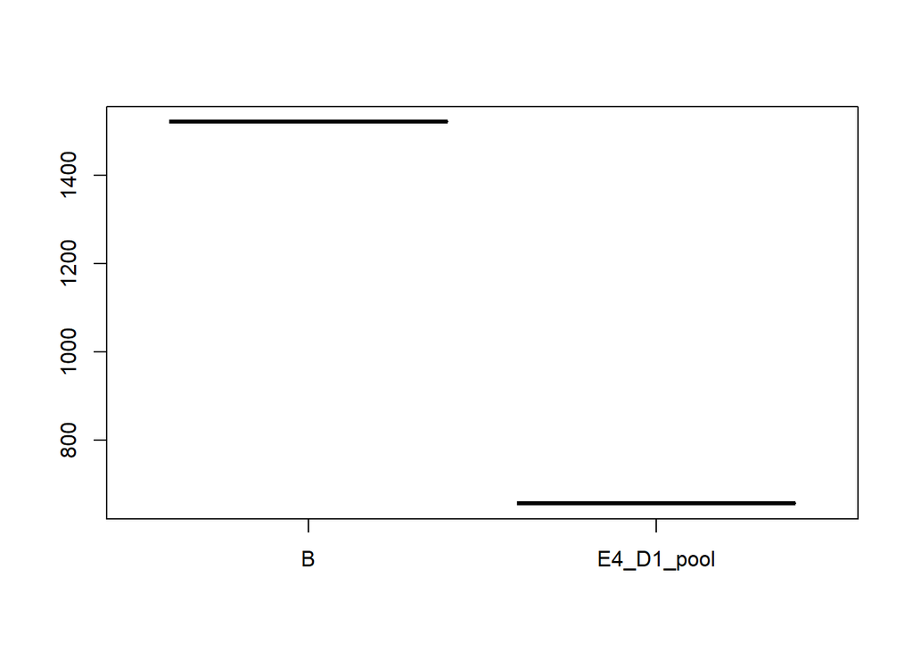

```r
#compare B to pool from 0609
B_raw <- readRDS(file = "results_v002/results_run1_mqpar_extracts_2gether_E4_D1_B_LFQ_combined_txt_proteinGroups.txt_Unique.RDS")
B_raw <- B_raw[[1]]
B <- dplyr::select(B_raw, contains("Pool_G"))
B <- apply(B, 1, any)
fasta <- c()
for (i in 1:length(B_raw$FASTA)){
  tmp <- strsplit(B_raw$FASTA[i],split='\\|')[[1]][2]
  fasta <- c(fasta,tmp)
}
B <- as.data.frame(cbind(B, fasta))
aj_raw <- readRDS(file = "results_v002/results_run1_mqpar_extracts_2gether_E4_D1_a-j_LFQ_combined_txt_proteinGroups.txt_Unique.RDS")
aj_raw <- aj_raw[[1]]
aj <- dplyr::select(aj_raw, contains("Pool"))
aj <- apply(aj, 1, any)
fasta <- c()
for (i in 1:length(aj_raw$FASTA)){
  tmp <- strsplit(aj_raw$FASTA[i],split='\\|')[[1]][2]
  fasta <- c(fasta,tmp)
}
aj <- as.data.frame(cbind(aj, fasta))
B_aj_comparison  <- merge(B, aj,
                             all = TRUE,
                             by = "fasta")

B_aj_comparison$B <- as.logical(B_aj_comparison$B)
B_aj_comparison$aj <- as.logical(B_aj_comparison$aj)
B_aj_comparison <- B_aj_comparison[,-1]*1
B_aj_comparison[B_aj_comparison==0] <- NA
boxplot(sum(B_aj_comparison$B,na.rm = TRUE),
        sum(B_aj_comparison$aj,na.rm = TRUE),
        names = c("B","E4_D1_pool"))
```

```r
proteins <- as.data.frame(which(!is.na(B_aj_comparison), arr.ind=TRUE))

B_inter <- proteins %>% dplyr::filter(col == 1)
aj_inter <- proteins %>% dplyr::filter(col == 2)

# combine to list
lst <- list("E4_D1_B_fractions"=as.double(B_inter[,1]),
            "E4_D1"=as.double(aj_inter[,1]))

upset(fromList(lst),
      order.by = "freq",
      nsets = 10,
      nintersects = 15,
      keep.order = TRUE,
      sets=c("E4_D1_B_fractions", "E4_D1"),
      mainbar.y.label = "Number of shared proteins",
      sets.x.label = "Number of proteins per fraction",
      set_size.show = TRUE,
      set_size.angles = 0,
      set_size.scale_max = 1800
)
```

[figure not shown]

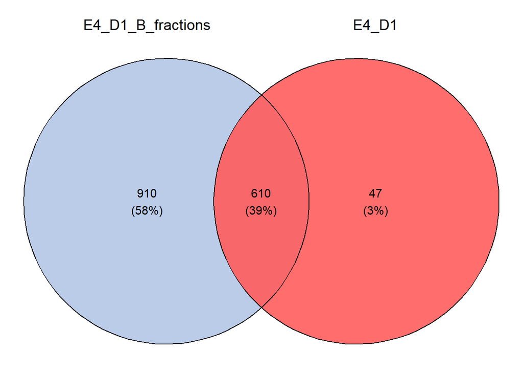

```r
ggvenn(lst,
       fill_color = c(IG,total),
       stroke_size = 0.5, set_name_size = 5, text_size = 4, digits = 0, fill_alpha = 0.9)
```

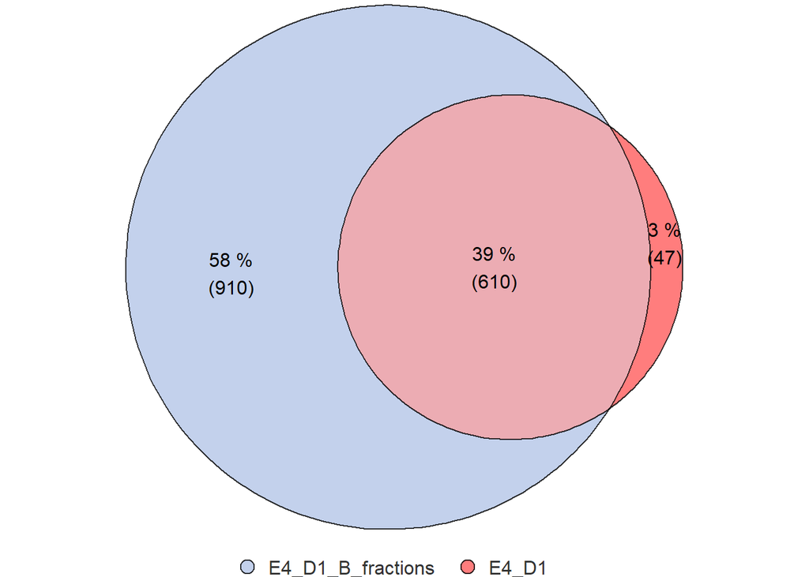

```r
#ggsave("./pics/unique_B_D1pool.png")

euler_venn_2comp(lst, label_venn = c("E4_D1_B_fractions","E4_D1"), color_venn = c(IG,total), cex_venn = c(1,1), h_just = 0.5, v_just = 0.5)
```

```r
print(c("B","E4_D1_pool"))
```

```
## [1] "B"          "E4_D1_pool"
```

```r
sum(B_aj_comparison$B,na.rm = TRUE)
```

```
## [1] 1520
```

```r
sum(B_aj_comparison$aj,na.rm = TRUE)
```

```
## [1] 657
```

## 4.1 compare E4_D1_Pool_G_B1-B9 and E4_D1_Pool_20_B1-B9

- um Unterschiede zwischen B1-B9 in Pool_G und Pool_20 zu sehen
- habe mir die Proteine auch angeschaut die unterschiedlich sind. 31 davon sind uncharacterized proteins
- teilweise sind sich die proteine schon ähnlich zumindest von der accesion number

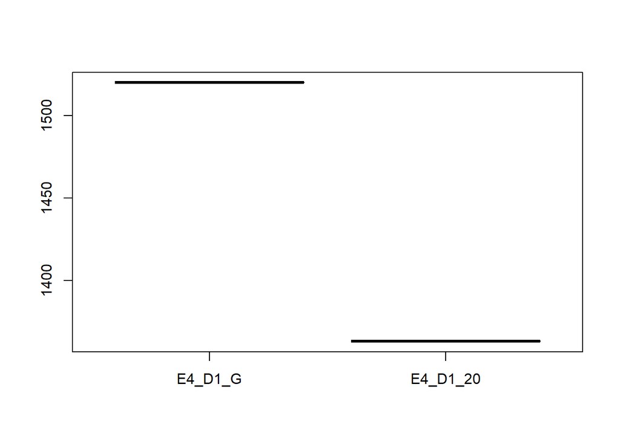

```r
#E4_D1_Pool_G_B1-B9
data <- readRDS(file = "results_v002/results_run1_mqpar_extracts_2gether_E4_D1_B_LFQ_combined_txt_proteinGroups.txt_Unique.RDS")
data <- data[[1]]
data_sub <- dplyr::select(data, contains("Pool_G"))
B_D1<-apply(data_sub, 1, any)
fasta <- c()
for (i in 1:length(data$FASTA)){
  tmp <- strsplit(data$FASTA[i],split='\\|')[[1]][2]
  fasta <- c(fasta,tmp)
}
B_D1 <- as.data.frame(cbind(B_D1, fasta))
#B_D1 <- as.data.frame(cbind(B_D1, data$FASTA))

#E4_D1_Pool_20_B1-B9

D1_raw <- readRDS(file = "results_v002/results_run1_mqpar_extracts_2gether_E4_D1_B_LFQ_combined_txt_proteinGroups.txt_Unique.RDS")
D1_raw <- D1_raw[[1]]
D1 <- dplyr::select(D1_raw, contains("20"))
D1 <- apply(D1, 1, any)
#D1 <- as.data.frame(cbind(D1, D1_raw$FASTA))
fasta <- c()
for (i in 1:length(data$FASTA)){
  tmp <- strsplit(data$FASTA[i],split='\\|')[[1]][2]
  fasta <- c(fasta,tmp)
}
D1 <- as.data.frame(cbind(D1, fasta))

G_pool_comparison  <- merge(B_D1, D1,
                           all = TRUE,
                           by = "fasta")

G_pool_comparison$B_D1 <- as.logical(G_pool_comparison$B_D1)
G_pool_comparison$D1 <- as.logical(G_pool_comparison$D1)
G_pool_comparison <- G_pool_comparison[,-1]*1
G_pool_comparison[G_pool_comparison==0] <- NA

# boxplot
boxplot(sum(G_pool_comparison$B_D1,na.rm = TRUE),
        sum(G_pool_comparison$D1,na.rm = TRUE),
        names = c("E4_D1_G","E4_D1_20"))
```

```r
proteins <- as.data.frame(which(!is.na(G_pool_comparison), arr.ind=TRUE))

B_D1_inter <- proteins %>% dplyr::filter(col == 1)
D1_inter <- proteins %>% dplyr::filter(col == 2)

# combine to list
lst <- list("E4_D1_G"=as.double(B_D1_inter[,1]),
            "E4_D1_20"=as.double(D1_inter[,1]))

upset(fromList(lst),
      order.by = "freq",
      nsets = 10,
      nintersects = 15,
      keep.order = TRUE,
      sets=c("E4_D1_G", "E4_D1_20"),
      mainbar.y.label = "Number of shared proteins",
      sets.x.label = "Number of proteins per fraction",
      set_size.show = TRUE,
      set_size.angles = 0,
      set_size.scale_max = 1000
)
```

[figure not shown]

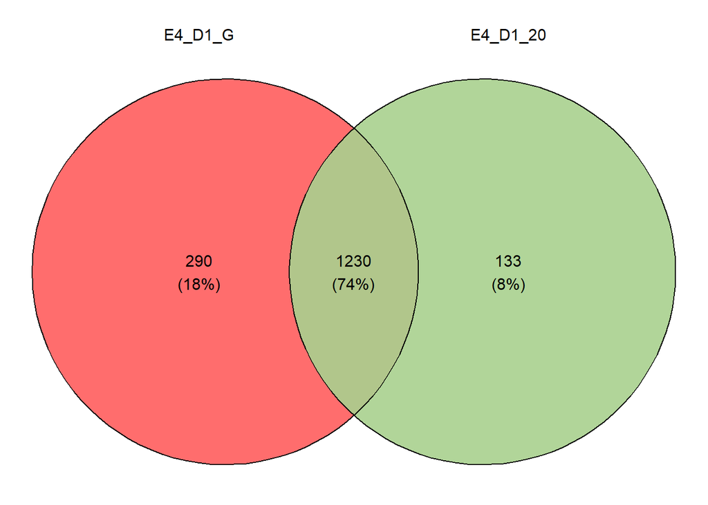

```r
#venn digarams
#get colors
D1_col <- rgb(255,93,93, maxColorValue = 255)
D2_col <- rgb(169,208,142,maxColorValue = 255)
#E4_D1_pool_col <- rgb(255,217,102, maxColorValue = 255)

ggvenn(lst,
       fill_color = c(D1_col,D2_col),
       stroke_size = 0.5, set_name_size = 4, text_size = 4, digits = 0, fill_alpha = 0.9)
```

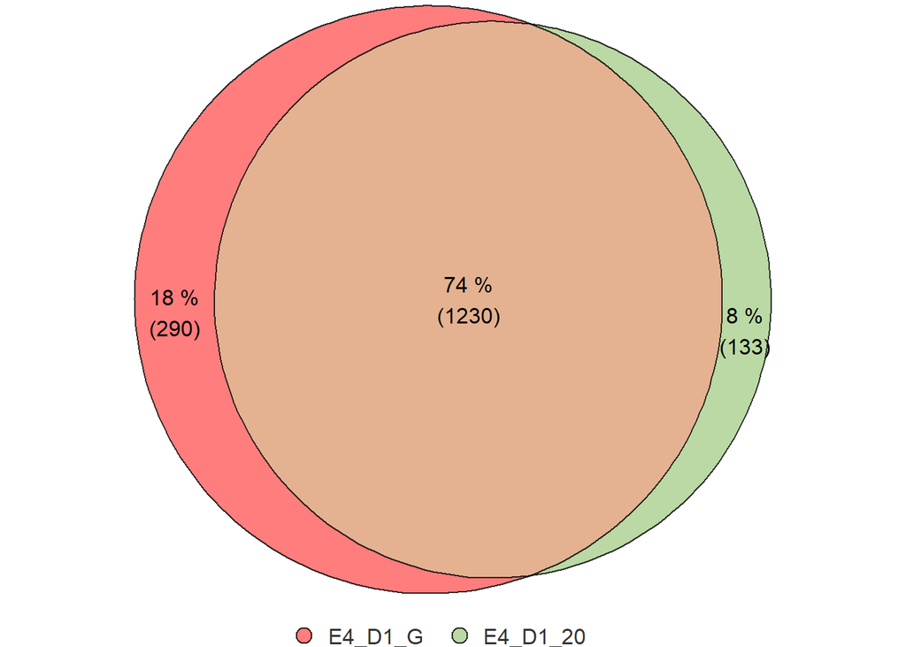

```r
euler_venn_2comp(lst, label_venn = c("E4_D1_G","E4_D1_20"), color_venn = c(D1_col,D2_col), cex_venn = c(1,1), h_just = 0.5, v_just = 0.5)
```

```r
print(c("E4_D1_G","E4_D1_20"))
```

```
## [1] "E4_D1_G"  "E4_D1_20"
```

```r
sum(G_pool_comparison$B_D1,na.rm = TRUE)
```

```
## [1] 1520
```

```r
sum(G_pool_comparison$D1,na.rm = TRUE)
```

```
## [1] 1363
```

# 5 Compare E3e E3f with E4_D1_a-j with E5_a_b

- E3 e bzw E3 f sollte dasselbe sein wie das hier `file:///X:/wissenschaftliche%20Ver%C3%B6ffentlichungen/Publikationen/2022/Proteomics_JRS_DL/data/results_v002/results_run1_mqpar_extracts_2gether_E4_D1_a-j_LFQ_combined_txt_proteinGroups.txt_post-processing.html#52_Summary_Unique` und auch E5_D1 a und b

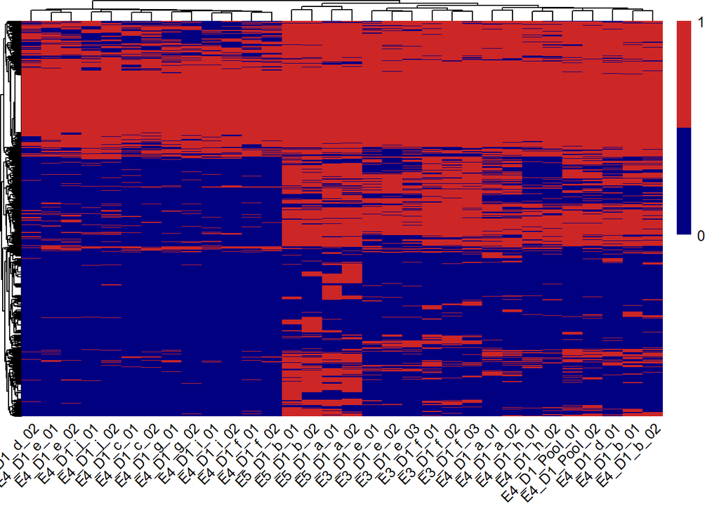

```r
aj_raw <- readRDS(file = "results_v002/results_run1_mqpar_extracts_2gether_E4_D1_a-j_LFQ_combined_txt_proteinGroups.txt_Unique.RDS")
aj_raw <- aj_raw[[1]]
aj <- aj_raw[,-ncol(aj_raw)]
FASTA <- c()
for (i in 1:length(aj_raw$FASTA)){
  tmp <- strsplit(aj_raw$FASTA[i],split='\\|')[[1]][2]
  FASTA<- c(FASTA,tmp)
}
aj <- cbind(aj,FASTA)

E3_D1_raw <- readRDS(file = "results_v002/results_run1_mqpar_extracts_2gether_E3_D1_LFQ_combined_txt_proteinGroups.txt_Unique.RDS")
E3_D1_raw <- E3_D1_raw[[1]]
E3_D1 <- E3_D1_raw[,c(13:18)]
FASTA <- c()
for (i in 1:length(E3_D1_raw$FASTA)){
  tmp <- strsplit(E3_D1_raw$FASTA[i],split='\\|')[[1]][2]
  FASTA<- c(FASTA,tmp)
}
E3_D1 <- cbind(E3_D1,FASTA)

E5_D1_raw <- readRDS(file="./27_20230201_FH/results/D5_extracts_Unique.RDS")
E5_D1_raw <- E5_D1_raw[[1]]
E5_D1 <- dplyr::select(E5_D1_raw, contains(".1"))
colnames(E5_D1) <- c(paste("Unique.peptides.","E5_D",substring(colnames(E5_D1),17),sep=""))
FASTA <- c()
for (i in 1:length(E5_D1_raw$FASTA)){
  tmp <- strsplit(E5_D1_raw$FASTA[i],split='\\|')[[1]][2]
  FASTA<- c(FASTA,tmp)
}
E5_D1 <- cbind(E5_D1,FASTA)


comp  <- merge(aj, E3_D1,
               all = TRUE,
               by = "FASTA")
comp <- merge(comp, E5_D1,
              all=TRUE,
              by="FASTA")


paletteLength <- 2
myColor <- colorRampPalette(c("navy", "white",
                              "firebrick3"))(paletteLength)
data4pheatmap <- comp[,-1]
data4pheatmap <- data4pheatmap*1
data4pheatmap[data4pheatmap == 0] <- NA
# remove NA rows
ind <- apply(data4pheatmap, 1, function(x) all(is.na(x)))
data4pheatmap_clear <- data4pheatmap[!ind,]
colnames(data4pheatmap_clear) <- colnames(comp[-1])
data4pheatmap_clear[is.na(data4pheatmap_clear)] <- 0
pheatmap(data4pheatmap_clear,
         legend_breaks = c(0,1),
         color = myColor,
         treeheight_row = 10,
         angle_col ="45",
         treeheight_col = 10,
         legend = TRUE,
         labels_row = rep("",nrow(data4pheatmap)),
         labels_col = substring(colnames(data4pheatmap_clear),17))
```

```r
#plot results
results_2gether <- sapply(comp[,-1],function(x)sum(x, na.rm = TRUE))
print(kable(results_2gether))
```

```
##
##
## |                              |   x|
## |:-----------------------------|---:|
## |Unique.peptides.E4_D1_a_01    | 575|
## |Unique.peptides.E4_D1_a_02    | 579|
## |Unique.peptides.E4_D1_b_01    | 592|
## |Unique.peptides.E4_D1_b_02    | 583|
## |Unique.peptides.E4_D1_c_01    | 308|
## |Unique.peptides.E4_D1_c_02    | 316|
## |Unique.peptides.E4_D1_d_01    | 546|
## |Unique.peptides.E4_D1_d_02    | 320|
## |Unique.peptides.E4_D1_e_01    | 370|
## |Unique.peptides.E4_D1_e_02    | 349|
## |Unique.peptides.E4_D1_f_01    | 330|
## |Unique.peptides.E4_D1_f_02    | 327|
## |Unique.peptides.E4_D1_g_01    | 332|
## |Unique.peptides.E4_D1_g_02    | 327|
## |Unique.peptides.E4_D1_h_01    | 490|
## |Unique.peptides.E4_D1_h_02    | 478|
## |Unique.peptides.E4_D1_i_01    | 328|
## |Unique.peptides.E4_D1_i_02    | 319|
## |Unique.peptides.E4_D1_j_01    | 336|
## |Unique.peptides.E4_D1_j_02    | 367|
## |Unique.peptides.E4_D1_Pool_01 | 590|
## |Unique.peptides.E4_D1_Pool_02 | 593|
## |Unique.peptides.E3_D1_e_01    | 534|
## |Unique.peptides.E3_D1_e_02    | 542|
## |Unique.peptides.E3_D1_e_03    | 544|
## |Unique.peptides.E3_D1_f_01    | 647|
## |Unique.peptides.E3_D1_f_02    | 623|
## |Unique.peptides.E3_D1_f_03    | 630|
## |Unique.peptides.E5_D1_a_01    | 755|
## |Unique.peptides.E5_D1_a_02    | 764|
## |Unique.peptides.E5_D1_b_01    | 743|
## |Unique.peptides.E5_D1_b_02    | 747|
```

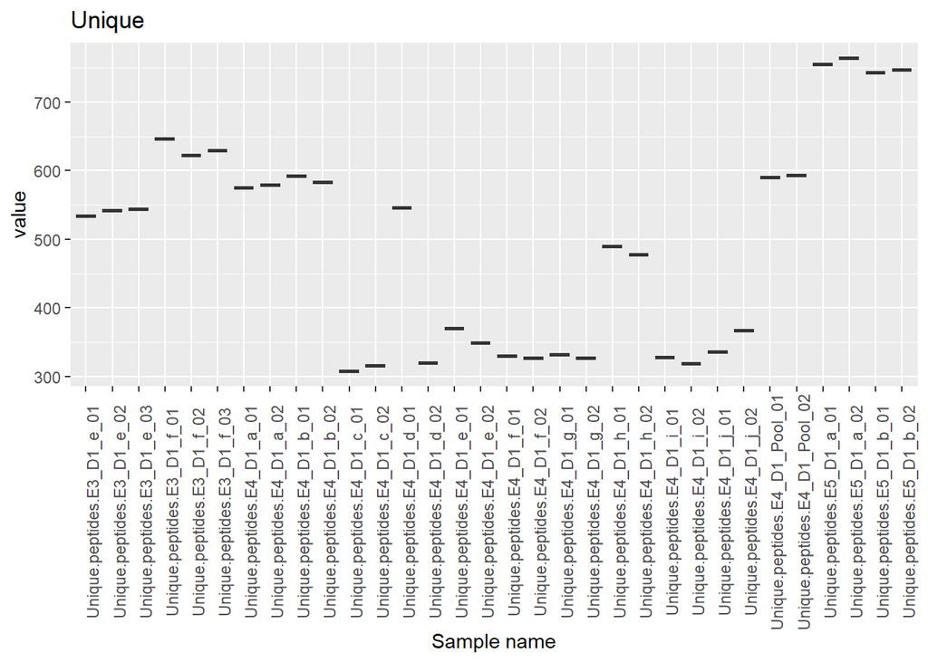

```r
ggplot(melt(results_2gether),aes(x = rownames(melt(results_2gether)), y = value)) +
  geom_boxplot() +
  xlab("Sample name") +
  theme(axis.text.x = element_text(angle = 90)) +
  labs(title = "Unique")
```

# 6 E4-D2

```r
#############################
# D2
###############################
data <- readRDS(file = "results_v002/results_run1_mqpar_extracts_2gether_D2_LFQ_combined_txt_proteinGroups.txt_Unique.RDS")
data <- data[[1]]
data_sub <- dplyr::select(data, contains("Pool_20"))
B_D2 <- data_sub*1
B_D2[B_D2==0] <- NA


### analysis B
proteins <- as.data.frame(which(!is.na(B_D2), arr.ind=TRUE))

B1 <- proteins %>% dplyr::filter(col == 1 ) # | col == 2 -> means or col2
B10 <- proteins %>% dplyr::filter(col == 2)
B2 <- proteins %>% dplyr::filter(col == 3)
B3 <- proteins %>% dplyr::filter(col == 4)
B4 <- proteins %>% dplyr::filter(col == 5)
B5 <- proteins %>% dplyr::filter(col == 6)
B6 <- proteins %>% dplyr::filter(col == 7)
B7 <- proteins %>% dplyr::filter(col == 8)
B8 <- proteins %>% dplyr::filter(col == 9)
B9 <- proteins %>% dplyr::filter(col == 10)
# combine to list
lst <- list(B1 = as.double(B1[,1]),
            B2 = as.double(B2[,1]),
            B3 = as.double(B3[,1]),
            B4 = as.double(B4[,1]),
            B5 = as.double(B5[,1]),
            B6 = as.double(B6[,1]),
            B7 = as.double(B7[,1]),
            B8 = as.double(B8[,1]),
            B9 = as.double(B9[,1]),
            B10 = as.double(B10[,1]))

upset(fromList(lst),
      order.by = "freq",
      nsets = 9,
      nintersects = 15,
      sets = c("B1","B2","B3","B4","B5","B6","B7","B8","B9","B10"),
      keep.order = TRUE,
      mainbar.y.label = "Number of shared proteins",
      sets.x.label = "Number of proteins per fraction",
      set_size.show = TRUE,
      set_size.angles = 0,
      set_size.scale_max = 1000
)
```

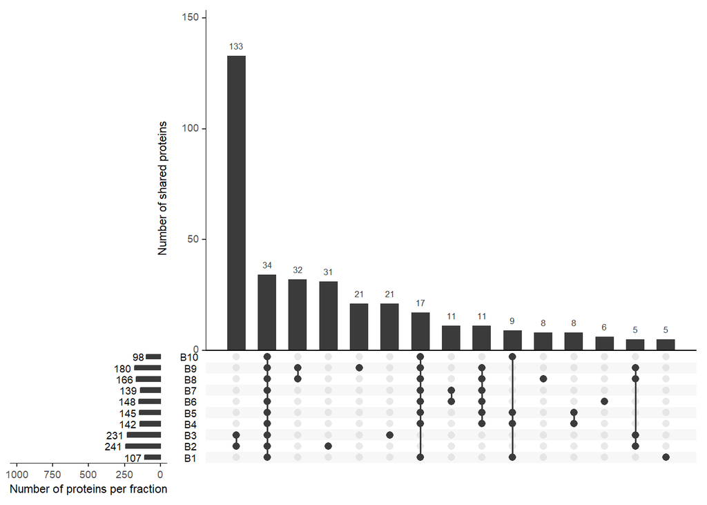

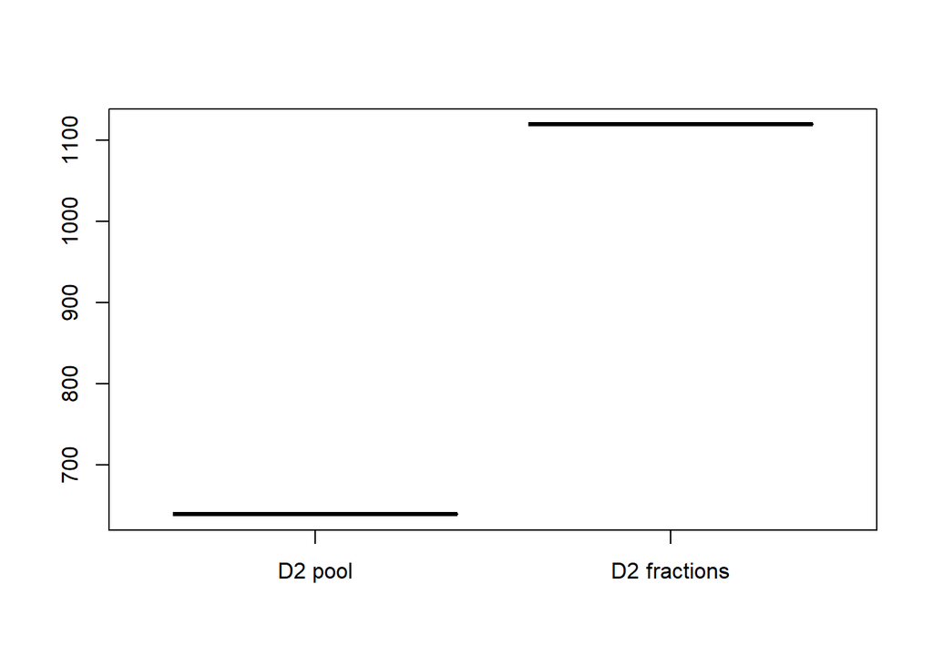

```r
data_D2_pool <- dplyr::select(data, contains("Gesamt"))
data_D2_pool <- apply(data_D2_pool, 1, any)
data_D2_fractions <- dplyr::select(data, contains("20"))
data_D2_fractions <- apply(data_D2_fractions, 1, any)
data_D2 <- as.data.frame(cbind(data_D2_pool,data_D2_fractions))
data_D2 <- data_D2*1
data_D2[data_D2==0] <- NA
# boxplot
boxplot(sum(data_D2$data_D2_pool,na.rm = TRUE),
        sum(data_D2$data_D2_fractions,na.rm = TRUE),
        names = c("D2 pool","D2 fractions"))
```

```r
proteins <- as.data.frame(which(!is.na(data_D2), arr.ind=TRUE))

D2_pool_inter <- proteins %>% dplyr::filter(col == 1)
D2_fractions_inter <- proteins %>% dplyr::filter(col == 2)

# combine to list
lst <- list(D2_pool=as.double(D2_pool_inter[,1]),
            D2_fractions=as.double(D2_fractions_inter[,1]))

upset(fromList(lst),
      order.by = "freq",
      nsets = 10,
      nintersects = 15,
      keep.order = TRUE,
      sets=c("D2_pool", "D2_fractions"),
      mainbar.y.label = "Number of shared proteins",
      sets.x.label = "Number of proteins per fraction",
      set_size.show = TRUE,
      set_size.angles = 0,
      set_size.scale_max = 1000
)
```

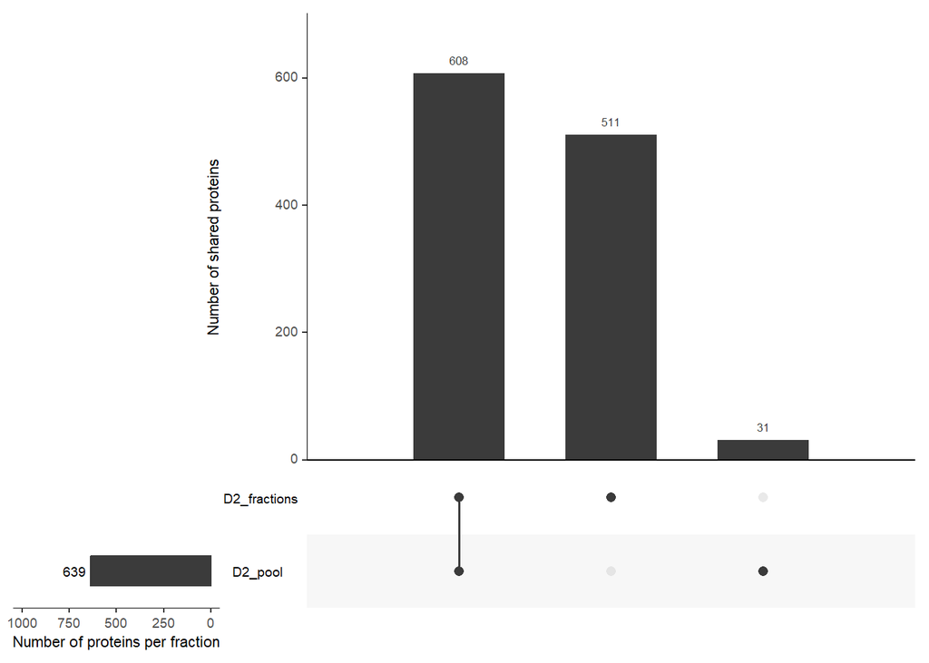

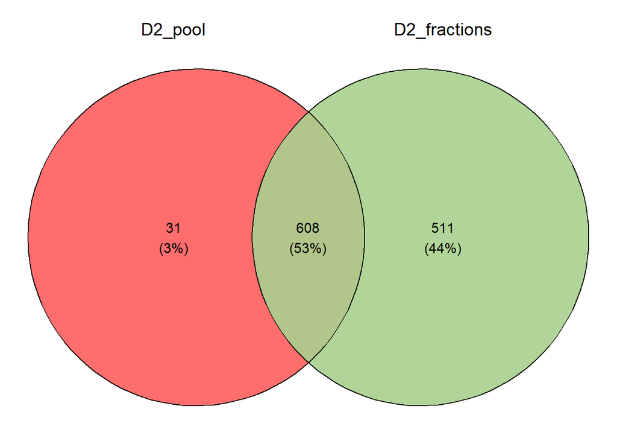

```r
#venn digarams
#get colors
D2_pool_col <- rgb(255,93,93, maxColorValue = 255)
D2_ingel_col <- rgb(169,208,142,maxColorValue = 255)
#E4_D1_pool_col <- rgb(255,217,102, maxColorValue = 255)

ggvenn(lst,
       fill_color = c(D2_pool_col,D2_ingel_col),
       stroke_size = 0.5, set_name_size = 5, text_size = 4, digits = 0, fill_alpha = 0.9)
```

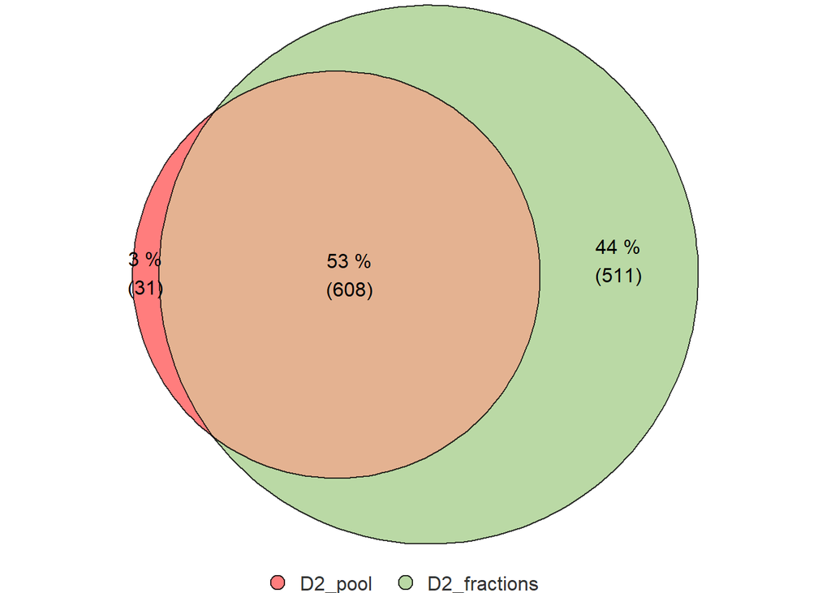

```r
euler_venn_2comp(lst, label_venn = c("D2_pool","D2_fractions"), color_venn = c(D2_pool_col,D2_ingel_col), cex_venn = c(1,1), h_just = 0.5, v_just = 0.5)
```

# 7 E4 - Compare D1-D2

## 7.1 fractions

### 7.1.1 E4_D1_Pool_G_B1-B9 with E4_D2_Pool_20_B1-B10

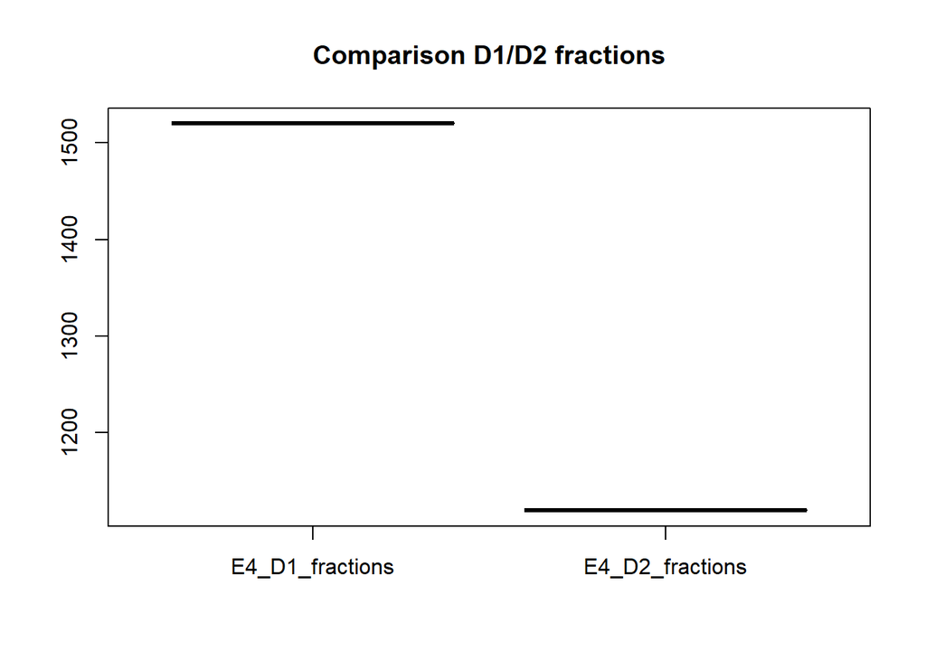

```r
#################### D1 fractions
data <- readRDS(file = "results_v002/results_run1_mqpar_extracts_2gether_E4_D1_B_LFQ_combined_txt_proteinGroups.txt_Unique.RDS")
data <- data[[1]]
data_sub <- dplyr::select(data, contains("Pool_G"))
B_D1<-apply(data_sub, 1, any)
fasta <- c()
for (i in 1:length(data$FASTA)){
  tmp <- strsplit(data$FASTA[i],split='\\|')[[1]][2]
  fasta <- c(fasta,tmp)
}
B_D1 <- as.data.frame(cbind(B_D1, fasta))
#B_D1 <- as.data.frame(cbind(B_D1, data$FASTA))


#################### D2 fractions
data <- readRDS(file = "results_v002/results_run1_mqpar_extracts_2gether_D2_LFQ_combined_txt_proteinGroups.txt_Unique.RDS")
data <- data[[1]]
data_sub <- dplyr::select(data, contains("Pool_20"))
B_D2<-apply(data_sub, 1, any)
fasta <- c()
for (i in 1:length(data$FASTA)){
  tmp <- strsplit(data$FASTA[i],split='\\|')[[1]][2]
  fasta <- c(fasta,tmp)
}
B_D2 <- as.data.frame(cbind(B_D2, fasta))
#B_D2 <- as.data.frame(cbind(B_D2, data$FASTA))
#D1_D2_comparison  <- merge(B_D1, B_D2,
#                           all = TRUE,
#                           by = "V2")
D1_D2_comparison  <- merge(B_D1, B_D2,
                           all = TRUE,
                           by = "fasta")

D1_D2_comparison$B_D1 <- as.logical(D1_D2_comparison$B_D1)
D1_D2_comparison$B_D2 <- as.logical(D1_D2_comparison$B_D2)
D1_D2_comparison <- D1_D2_comparison[,-1]*1
D1_D2_comparison[D1_D2_comparison==0] <- NA

# boxplot
boxplot(sum(D1_D2_comparison$B_D1,na.rm = TRUE),
        sum(D1_D2_comparison$B_D2,na.rm = TRUE),
        names = c("E4_D1_fractions","E4_D2_fractions"),
        main="Comparison D1/D2 fractions")
```

```r
#upset r & ggvenn
proteins <- as.data.frame(which(!is.na(D1_D2_comparison), arr.ind=TRUE))

D1_inter <- proteins %>% dplyr::filter(col == 1)
D2_inter <- proteins %>% dplyr::filter(col == 2)

# combine to list
lst <- list("E4_D1_fraction"=as.double(D1_inter[,1]),
            "E4_D2_fraction"=as.double(D2_inter[,1]))

upset(fromList(lst),
      order.by = "freq",
      nsets = 10,
      nintersects = 15,
      keep.order = TRUE,
      sets=c("E4_D1_fraction", "E4_D2_fraction"),
      mainbar.y.label = "Number of shared proteins",
      sets.x.label = "Number of proteins per fraction",
      set_size.show = TRUE,
      set_size.angles = 0,
      set_size.scale_max = 1000
)
```

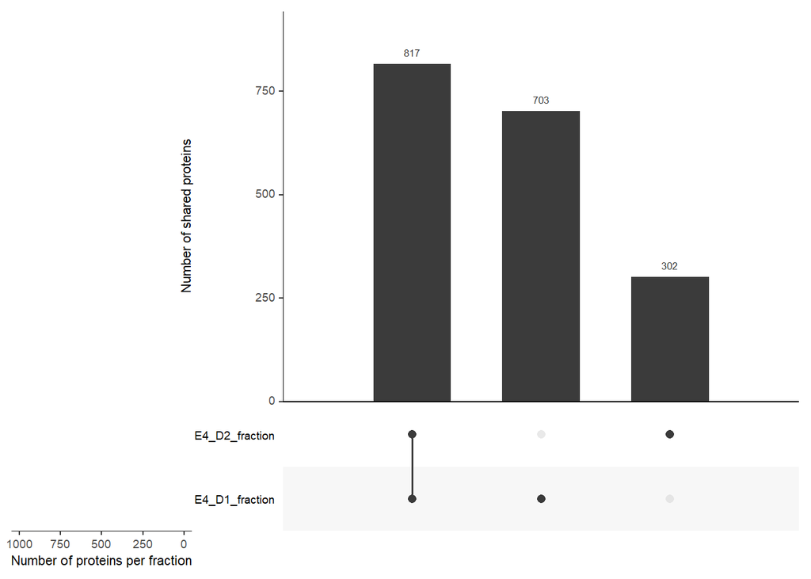

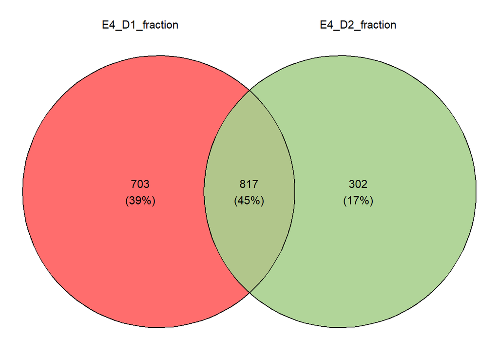

```r
#venn digarams
#get colors
D1_col <- rgb(255,93,93, maxColorValue = 255)
D2_col <- rgb(169,208,142,maxColorValue = 255)
#E4_D1_pool_col <- rgb(255,217,102, maxColorValue = 255)

ggvenn(lst,
       fill_color = c(D1_col,D2_col),
       stroke_size = 0.5, set_name_size = 4, text_size = 4, digits = 0, fill_alpha = 0.9)
```

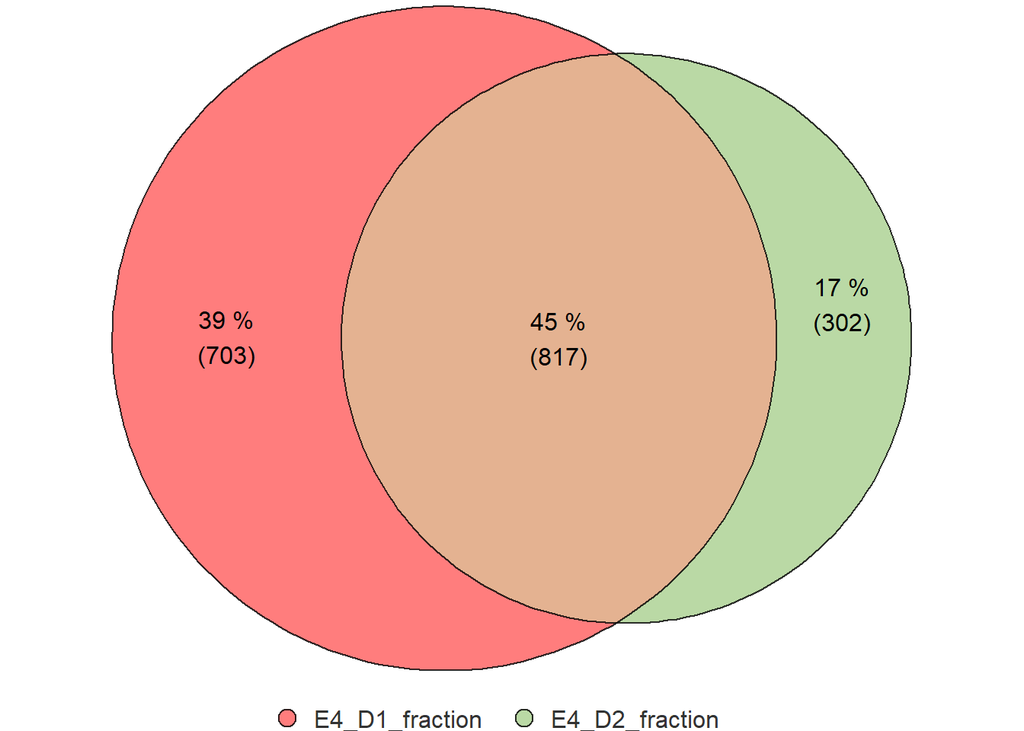

```r
euler_venn_2comp(lst, label_venn = c("E4_D1_fraction","E4_D2_fraction"), color_venn = c(D1_col,D2_col), cex_venn = c(1,1), h_just = 0.5, v_just = 0.5)
```

```r
print(c("E4_D1_fractions","E4_D2_fractions"))
```

```
## [1] "E4_D1_fractions" "E4_D2_fractions"
```

```r
sum(D1_D2_comparison$B_D1,na.rm = TRUE)
```

```
## [1] 1520
```

```r
sum(D1_D2_comparison$B_D2,na.rm = TRUE)
```

```
## [1] 1119
```

### 7.1.2 E4_D1_Pool_20_B1-B9 with E4_D2_Pool_20_B1-B10

```r
# D1-D2 comparison

D1_raw <- readRDS(file = "results_v002/results_run1_mqpar_extracts_2gether_E4_D1_B_LFQ_combined_txt_proteinGroups.txt_Unique.RDS")
D1_raw <- D1_raw[[1]]
D1 <- dplyr::select(D1_raw, contains("20"))
D1 <- apply(D1, 1, any)
#D1 <- as.data.frame(cbind(D1, D1_raw$FASTA))
fasta <- c()
for (i in 1:length(data$FASTA)){
  tmp <- strsplit(data$FASTA[i],split='\\|')[[1]][2]
  fasta <- c(fasta,tmp)
}
D1 <- as.data.frame(cbind(D1, fasta))
```

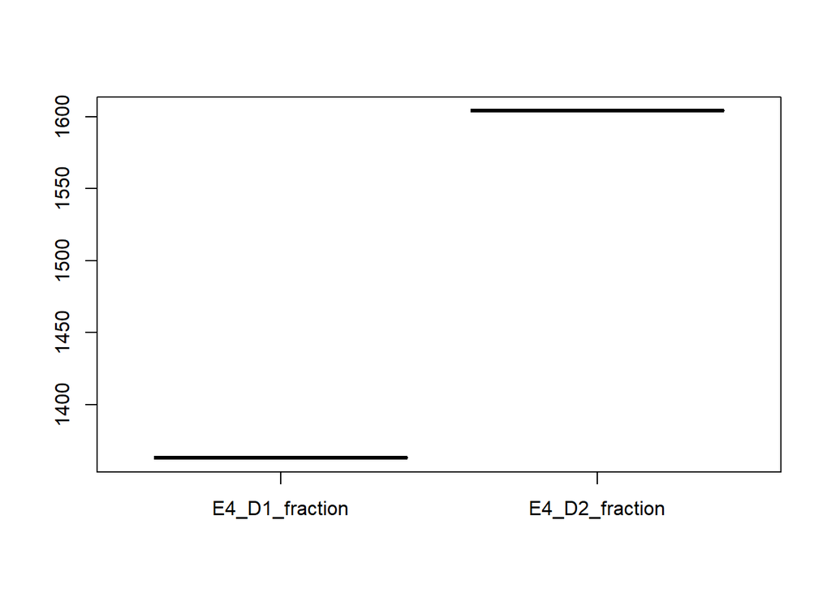

```r
D2_raw <- readRDS(file = "results_v002/results_run1_mqpar_extracts_2gether_D2_LFQ_combined_txt_proteinGroups.txt_Unique.RDS")
D2_raw <- D2_raw[[1]]
D2 <- dplyr::select(D2_raw, contains("Pool_20"))
D2 <- apply(D2, 1, any)
fasta <- c()
for (i in 1:length(data$FASTA)){
  tmp <- strsplit(data$FASTA[i],split='\\|')[[1]][2]
  fasta <- c(fasta,tmp)
}
#D2 <- as.data.frame(cbind(D2, D2_raw$FASTA))
D2 <- as.data.frame(cbind(D2, fasta))
D1_D2_comparison  <- merge(D1, D2,
                           all = TRUE,
                           by = "fasta")

D1_D2_comparison$D1 <- as.logical(D1_D2_comparison$D1)
D1_D2_comparison$D2 <- as.logical(D1_D2_comparison$D2)
D1_D2_comparison <- D1_D2_comparison[,-1]*1
D1_D2_comparison[D1_D2_comparison==0] <- NA

# boxplot
boxplot(sum(D1_D2_comparison$D1,na.rm = TRUE),
        sum(D1_D2_comparison$D2,na.rm = TRUE),
        names = c("E4_D1_fraction","E4_D2_fraction"))
```

```r
proteins <- as.data.frame(which(!is.na(D1_D2_comparison), arr.ind=TRUE))

D1_inter <- proteins %>% dplyr::filter(col == 1)
D2_inter <- proteins %>% dplyr::filter(col == 2)

# combine to list
lst <- list("E4_D1_fraction"=as.double(D1_inter[,1]),
            "E4_D2_fraction"=as.double(D2_inter[,1]))

upset(fromList(lst),
      order.by = "freq",
      nsets = 10,
      nintersects = 15,
      keep.order = TRUE,
      sets=c("E4_D1_fraction", "E4_D2_fraction"),
      mainbar.y.label = "Number of shared proteins",
      sets.x.label = "Number of proteins per fraction",
      set_size.show = TRUE,
      set_size.angles = 0,
      set_size.scale_max = 1000
)
```

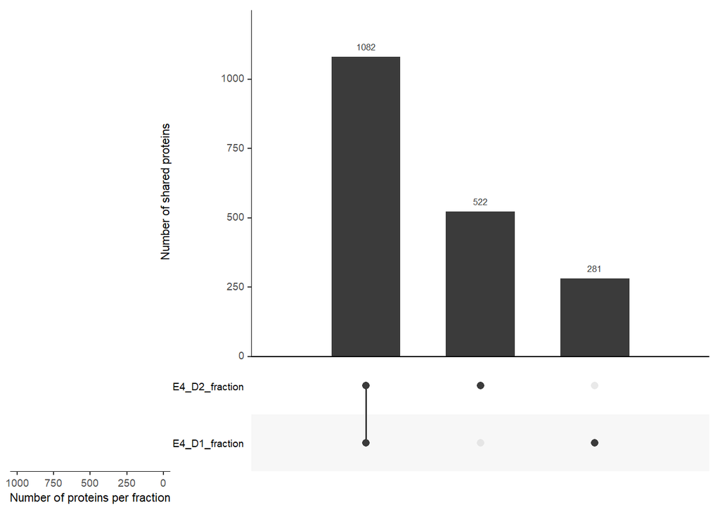

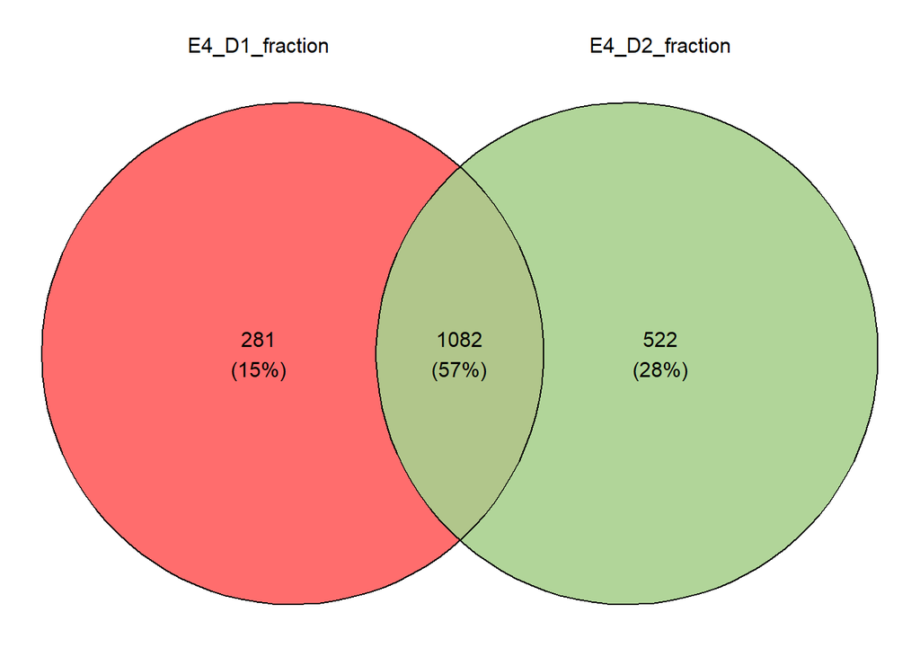

```r
#venn digarams
#get colors
D1_col <- rgb(255,93,93, maxColorValue = 255)
D2_col <- rgb(169,208,142,maxColorValue = 255)
#E4_D1_pool_col <- rgb(255,217,102, maxColorValue = 255)

ggvenn(lst,
       fill_color = c(D1_col,D2_col),
       stroke_size = 0.5, set_name_size = 4, text_size = 4, digits = 0, fill_alpha = 0.9)
```

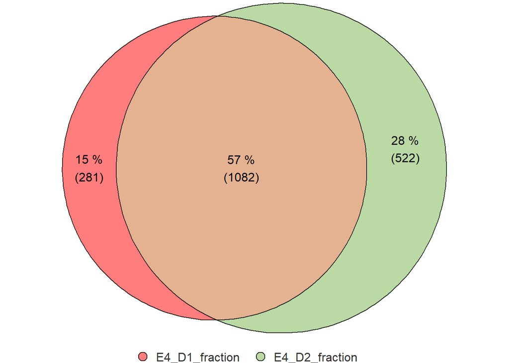

```r
euler_venn_2comp(lst, label_venn = c("E4_D1_fraction","E4_D2_fraction"), color_venn = c(D1_col,D2_col), cex_venn = c(1,1), h_just = 0.5, v_just = 0.5)
```

```r
print(c("E4_D1_fraction","E4_D2_fraction"))
```

```
## [1] "E4_D1_fraction" "E4_D2_fraction"
```

```r
sum(D1_D2_comparison$D1,na.rm = TRUE)
```

```
## [1] 1363
```

```r
sum(D1_D2_comparison$D2,na.rm = TRUE)
```

```
## [1] 1604
```